# Презентация по лабораторной работе №4

Базовая настройка HTTP-сервера Apache

Лушин А.А.

Российский университет дружбы народов, Москва, Россия

Факультет Физико-математических и естественных наук

# Информация

## Докладчик

- Лушин Артём Андреевич
- Бакалавр направления компьютерные и информационные науки
- Кафедра теории вероятности и кибербезопасности
- Российский университет дружбы народов
- lusin5745@gmail.com

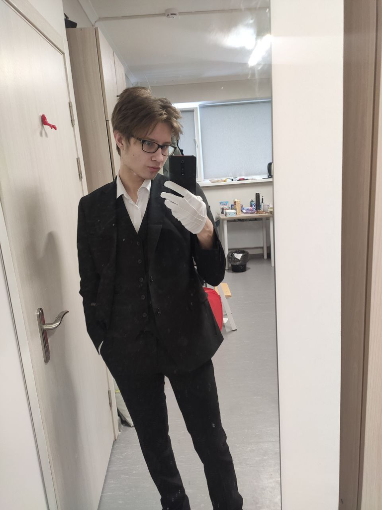

# Вводная часть

## Цели и задачи

Приобретение практических навыков по установке и базовому конфигурированию HTTP-сервера Apache.

# Ход работы

## Конфигурация HTTP-сервера

Внесли изменения в настройки межсетевого узла сервер и разрешили работу с HTTP. Активировали и запустили HTTP-сервер. через лог систем проверили, что всё работает.

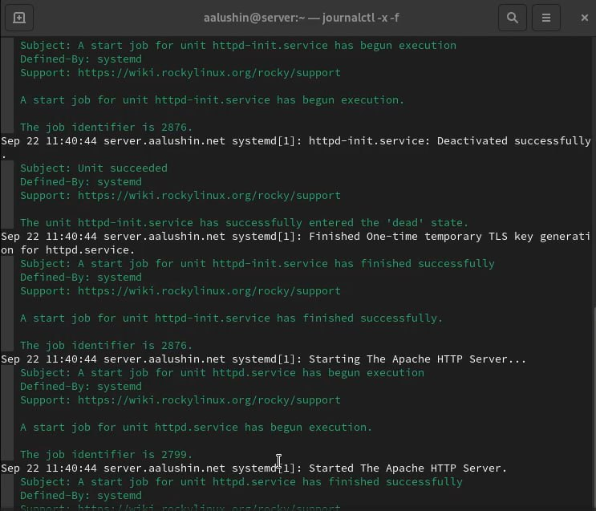

## Анализ HTTP-сервера

Запустили вторую машину клиент, чтобы проверить работу сервера. Просмотрели лог ошибок работы сервера, а также запустили мониторинг доступа к серверу. На клиенте запустили браузер и зашли на сайт.

[figure not shown]

## Настройки хостинга HTTP-сервера

Остановили работу днс-сервера, чтобы внести изменения. Добавили записи в файлы прямой и обратной днс-зоны, удалили файлы jnl. Перезапустили днс-сервер. Создали два файла для двух веб-сервером, внесли соответствующие скрипты. Также создали два файла, которые будут содержать текстовые страницы веб-страниц. Скорректировали права доступа в каталог с веб-контентом. Восстановили метки безопасности. Через машину клиент убедились, что две веб-страницы работают.

[figure not shown]

## Изменения внутреннего окружения

Создал каталог http, в который перенёс все конфигурационные файлы. Заменил конфигурационные файлы днс-сервера. Создал исполняемый файл http.sh, прописал скрипт, который выполняет все произведённые действия. В Vagrantfile внёс изменения, чтобы скрипт отрабатывал во время загрузки машины.

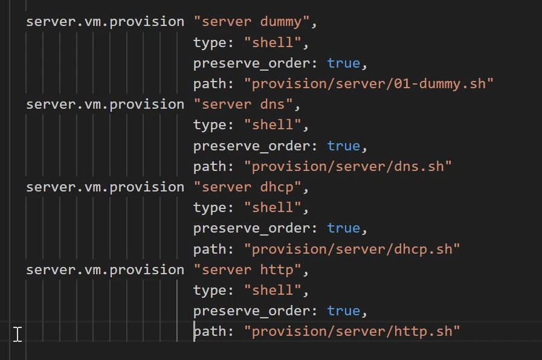

# Результаты

## Вывод

Я приобрёл практические навыки по установке и базовому конфигурированию HTTP-сервера Apache.

## Контрольные вопросы

1. Через какой порт по умолчанию работает Apache?
- По умолчанию Apache работает через порт 80.
2. Под каким пользователем запускается Apache и к какой группе относится этот пользователь?
- Apache обычно запускается под пользователем “www-data” и относится к группе “www-data”.
3. Где располагаются лог-файлы веб-сервера? Что можно по ним отслеживать?
- Лог-файлы веб-сервера обычно располагаются в каталоге /var/log/apache2. Можно отслеживать доступ, ошибки, запросы и другую информацию.
4. Где по умолчанию содержится контент веб-серверов?
- Контент веб-серверов по умолчанию содержится в каталоге /var/www/html.
5. Каким образом реализуется виртуальный хостинг? Что он даёт?
- Виртуальный хостинг реализуется через конфигурацию веб-сервера, позволяя одному серверу обслуживать несколько доменов. Он дает возможность размещать несколько веб-сайтов на одном сервере.